# Model selection and plotting performance

Model selection and plotting performance Nova F. Smedley 2018-11-04

The package `gbmSPM` can be used to do the exact analysis pipeline used in the paper,

Smedley, Nova F., Benjamin M. Ellingson, Timothy F. Cloughesy, and William Hsu. “Longitudinal Patterns in Clinical and Imaging Measurements Predict Residual Survival in Glioblastoma Patients.” *Scientific reports* 8, no. 1 (2018): 14429.

See also Supplemental Materials.

## Vignette Info

This vignette shows how temporal features and patient covariates are used in predicting residual survival. This uses dummy patient data and follows the other vignettes “Generate sequential patterns” and “Predicting residual survival.”

## Example

1. **Create a few types of temporal features**

   To use dummy data, run `example_spm.R` from the `examples` folder in the terminal:

   ```
   $ Rscript /PATHTO/example_spm.R --tType 'rate' --minSupp 0.2 --minSuppList 'yes' --maxgap 60 --maxlength 2 --maxsize 2 --outDir ~/gbm_spm_example_multi
   ```

   Optionally: repeat the above for `tType` of `p` for percent change instead of rate change in tumor volume measurements:

   ```
   $ Rscript /PATHTO/example_spm.R --tType 'p' --minSupp 0.2 --minSuppList 'yes' --maxgap 60 --maxlength 2 --maxsize 2 --outDir ~/gbm_spm_example_multi
   ```

   This will generate patterns and feature vectors stored in `gbm_spm_example_multi`.
2. **Use the generated features in predicting residual survival**

   To use dummy data, run `example_logit_spm.R` from the `examples` folder for the different SPM parameters:

   ```
   $ Rscript example_logit_spm.R --tType 'rate' --maxgap 60 --maxlength 2 --lmax 0.2 --llength 100 --dataFolder sup0.4g60l2z2 --prefix logits --dir ~/gbm_spm_example_multi --saveLogit yes
   ```

   Optionally: again, repeat the above for the different SPM patterns created:
   - `sup0.2g60l2z2`
   - `sup0.25g60l2z2`
   - `sup0.3g60l2z2`
   - `sup0.35g60l2z2`
   - `sup0.4g60l2z2`

   and/or also repeat for another `tType` of `p` for percent change.

   This will perform repeated 2-fold cross-validation for hyperparameter selection. Experiment logs and logit model (and results) are also stored in `gbm_spm_example_multi`.
3. **Load functions to format logit results**

   These are functions for processing the data, which were stored and named in a specific manner that would likely be different than how users may use `gbmSPM`.

   ```r
   library(gbmSpm)
   library(grid)
   library(scales)
   library(wesanderson)

   getCVResults <- function(dir, fn, name) {
     cvResultsFile <- file.path(dir,fn)
     cvResults <- read.table(cvResultsFile, header=T, sep=',')

     # identify the cspade parameters the logit's features were based on
     temp <- do.call(rbind, lapply(cvResults$model, function(n) regmatches(n, gregexpr('[0-9]+',n))[[1]][2:5] ) )
     colnames(temp) <- c('support', 'gap', 'length', 'size')
     temp <- as.data.frame(temp)
     temp$support <- paste0( '.', as.character(temp$support))
     cvResults <- cbind(cvResults, temp)

     cvResults <- cvResults[order(cvResults$model),]
     cvResults$name <- rep(name, nrow(cvResults))

     ind <- length(strsplit(as.character(cvResults$model[1]), '\\/')[[1]])
     temp <- strsplit(as.character(cvResults$model),'\\/')
     cvResults$model <- unlist(lapply(temp, '[[', ind))
     cat('duplicates?: ', which(duplicated((cvResults))) )
     return(cvResults)
   }

   getCVByMonth <- function(cvResults, month, metricColName) {
     cv <- cvResults[cvResults$month==month,]
     cv <- cv[order(-cv[,metricColName]),]
     cv$model <- factor(cv$model, levels=unique(cv$model)) # order levels by decreasing ROC
     cv$name <- as.factor(cv$name)
     cv$group <- paste0(cv$tType, cv$name)
     cv$tType <- as.factor(cv$tType)
     cv$tType <- factor(cv$tType, levels=levels(cv$tType)[c(3,1,2,4)])
     cv
   }

   rankModels <- function(cvsResults, months, topN, metricColName) {
     r <- lapply(months, function(m) {
       models <- unique(cvsResults$model)
       ranked <- lapply(models, function(m) {
         results <- max(cvsResults[cvsResults$model==m,metricColName])
       })
       names(ranked) <- models
       ranked <- unlist(ranked)
       ranked <- ranked[order(-ranked)]
       names(ranked)[1:topN]
     })
     r <- unlist(r)
     r <- r[!duplicated(r)]
     return(r)
   }
   ```

   ROC and PR plotting functions:

   ```r
   # performance plot constants
   perfTheme <- theme(legend.text=element_text(size=8, color="grey30"),
                      legend.title=element_text(size=8),
                      legend.text.align =1,
                      legend.position='right',
                      legend.key.size=unit(.8,'line'),
                      legend.margin=margin(l = -0.15, unit='cm'),
                      legend.background = element_rect(fill = "transparent", colour = "transparent"),
                      axis.text=element_text(size=10, color="#666666"),
                      axis.title.y = element_text(margin=margin(0,5,0,0),size=8, angle=0, vjust=0.5),
                      axis.title.x = element_text(margin=margin(5,0,-5,0),size=8),
                      panel.spacing = unit(.35, "lines"),
                      strip.text.x = element_text(size=9,margin = margin(.05,0,.05,0, "cm")))
   scaleX <- scale_x_continuous(limits=c(0,1),breaks=seq(0,1,0.2))
   scaleY <- scale_y_continuous(limits=c(0,1),breaks=seq(0,1,0.2))
   perfGuide <- guides(colour = guide_legend(override.aes = list(size=3)))

   # see https://learnr.wordpress.com/2009/04/29/ggplot2-labelling-data-series-and-adding-a-data-table/

   vplayout <- function(...) {
     grid.newpage()
     pushViewport(viewport(layout = Layout))
   }
   subplot <- function(x, y) viewport(layout.pos.row = x,
                                      layout.pos.col = y)
   mmplot <- function(a, b) {
     vplayout()
     print(a, vp = subplot(1, 1))
     print(b, vp = subplot(2, 1))
   }
   # end
   Layout <- grid.layout(nrow = 2, ncol = 1, heights = unit(c(2,0.5), c("null", "null")))
   pd <- position_dodge(0.6) # move them .05 to the left and right

   # ROC
   plotCVResults <- function(cv, month, filename) {
     g <- ggplot(cv, aes(x=model, y=rocAUC, colour=tType, line=tType, group=group) ) +
       geom_point() + geom_line() +
       scale_y_continuous('Average\nArea Under the ROC Curve\n',limits=c(0.4,0.7),breaks=seq(0.4,0.7,.05), minor_breaks=seq(0.4,0.7,0.01)) +
       theme_linedraw() +
       ggtitle(month) +
       theme(axis.text.x=element_blank(),
             axis.title.x=element_blank(),
             axis.text=element_text(size=8),
             axis.title.y = element_text(angle = 90, vjust = .5, size=8, margin=margin(0,10,0,0)),
             legend.text=element_text(size=8, color='grey30'),
             legend.title=element_text(size=8),
             legend.position = c(0.7,0.8),
             legend.key.size=unit(.8,'line'),
             plot.title = element_text(size=8, hjust=0.5)) +
       labs(color='tumor volume type') +
       scale_color_manual(values = wes_palette("Darjeeling1")[-4] )

     table <- cv[!(duplicated(cv$model)),]
     table <- table[, c('model','size','length','gap','support')]
     table <- melt(table, id='model')

     t <- ggplot(table, aes(x=model,y=variable, label=format(value))) +
       geom_text(size = 4.2, color='grey30', hjust=0.6) + theme_bw() + scale_y_discrete('cSPADE\nparameters') +  scale_x_discrete(expand=c(0.1,0)) +
       theme(panel.grid.major = element_blank(), legend.position = "none",
             panel.border = element_blank(),
             axis.text.x = element_blank(),
             axis.ticks = element_blank(),
             axis.text=element_text(size=8),
             axis.title.y = element_text(angle = 90, vjust = .5, size=8, margin=margin(0,11,0,5)) ) +
       theme(plot.margin = unit(c(0,.19, 0, 0), "lines")) + xlab(NULL) + ylab(NULL)

     a <- mmplot(g, t)
   }

   # PR
   plotCVResults_PR <- function(cv, month, filename, lp) {
     g <- ggplot(cv, aes(x=model, y=prAUC, colour=tType, line=tType, group=group) ) +
       geom_point() + geom_line() +
       scale_y_continuous('Average\nArea Under the PR Curve\n',limits=c(0,0.2),breaks=seq(0,0.2,.05), minor_breaks=seq(0,0.2,0.01)) +
       theme_linedraw() +
       ggtitle(month) +
       theme(axis.text.x=element_blank(),
             axis.title.x=element_blank(),
             axis.text=element_text(size=8),
             axis.title.y = element_text(angle = 90, vjust = .5, size=8, margin=margin(0,13,0,0)),
             legend.text=element_text(size=8, color='grey30'),
             legend.title=element_text(size=8),
             legend.position=lp,
             legend.key.size=unit(.8,'line'),
             plot.title = element_text(size=8, hjust=0.5)) +
       labs(color='tumor volume type') +
       scale_color_manual(values = wes_palette("Darjeeling1")[-4] )

     table <- cv[!(duplicated(cv$model)),]
     table <- table[, c('model','size','length','gap','support')]
     table <- melt(table, id='model')

     t <- ggplot(table, aes(x=model,y=variable, label=format(value))) +
       geom_text(size = 4.2, color='grey30', hjust=0.6) + theme_bw() + scale_y_discrete('cSPADE\nparameters') +  scale_x_discrete(expand=c(0.1,0)) +
       theme(panel.grid.major = element_blank(), legend.position = "none",
             panel.border = element_blank(),
             axis.text.x = element_blank(),
             axis.ticks = element_blank(),
             axis.text=element_text(8),
             axis.title.y = element_text(angle = 90, vjust = .5, size=8, margin=margin(0,11,0,5)) ) +
       theme(plot.margin = unit(c(0,.19, 0, 0), "lines")) + xlab(NULL) + ylab(NULL)

     a <- mmplot(g, t)
   }
   ```

4. **Parse the cross-validation log files**

   The following assumes a specific location and format of the log file (e.g., the rows skipped while reading `.log` files)

   ```r
   dataDir <- '~/gbm_spm_example_multi/logits'
   theseDirs <- list.dirs(path=dataDir, full.names=F, recursive=F)
   theseDirs
   ```

   ```
   #> [1] "sup0.25g60l2z2" "sup0.2g60l2z2"  "sup0.35g60l2z2" "sup0.3g60l2z2"
   #> [5] "sup0.4g60l2z2"
   ```

   ```r
   # types and typenames are matched
   types <- c('percent','rateChange') # tumor volume types expected in log filename
   typenames <- c('percent change','rate change') # corresponding pretty names of tumor volume types
   months <- c('2-month','6-month','9-month', '12-month') # month names for classification labels

   cvs <- lapply(theseDirs, function(f) {
     cat(f, '\n')
     logFiles <- list.files(path=file.path(dataDir,f), pattern='\\.log$') # locate log files

     # extract results for each tumor volume type
     results <- lapply(seq(1,length(types)), function(i) {
       n <- logFiles[grepl(types[i],logFiles)] # read in a log file
       if (length(n) > 0) {
         log <- file.path(dataDir,f,n)
         con <- file(log)
         open(con)
         resultsCols <- read.table(con, skip=114, nrow=1, stringsAsFactors = F)  # expected results colnames
         r2 <- read.table(con, skip=0, nrow=1) # expected location of CV results for each classification
         r6 <- read.table(con, skip=25, nrow=1)
         r9 <- read.table(con, skip=25, nrow=1)
         r12 <- read.table(con, skip=25, nrow=1)
         close(con)

         r <- do.call('rbind', list(r2,r6,r9,r12)) # combine and format
         r <- r[,-1]
         colnames(r) <- c(resultsCols[1,])

         r$month <- months # attach additional info
         r$tType <- rep(typenames[i], nrow(r))
         r$model <- rep(f, nrow(r))
         temp <- do.call(rbind, lapply(r$model, function(n) regmatches(n, gregexpr('[0-9]+',n))[[1]][2:5] ) )
         colnames(temp) <- c('support', 'gap', 'length', 'size')
         temp <- as.data.frame(temp)
         temp$support <- paste0( '.', as.character(temp$support))
         r <- cbind(r, temp)
         r$name <- 'without'
         r
       } else {
         cat('\t ... file not found for ', typenames[i] , '\n')
       }
     })
     results <- do.call('rbind',results)
   })
   ```

   ```
   #> sup0.25g60l2z2
   #> sup0.2g60l2z2
   #> sup0.35g60l2z2
   #> sup0.3g60l2z2
   #> sup0.4g60l2z2
   ```

   ```r
   cvs <- do.call('rbind',cvs)
   cat('duplicates?: ', which(duplicated((cvs))) )
   ```

   ```
   #> duplicates?:
   ```

   ```r
   cvs[1:5,]
   ```

   ```
   #>        prAUC    rocAUC     prAUCSD   rocAUCSD     lambda    month
   #> 1 0.04622387 0.5598533 0.013537090 0.03944685 0.05437176  2-month
   #> 2 0.06864538 0.5304702 0.011415910 0.07776483 0.03414705  6-month
   #> 3 0.10674390 0.5494308 0.021065460 0.01920351 0.03111352  9-month
   #> 4 0.13006210 0.5494858 0.089507720 0.04368807 0.09501620 12-month
   #> 5 0.01244991 0.5882589 0.006009641 0.06704849 0.20000000  2-month
   #>            tType          model support gap length size    name
   #> 1 percent change sup0.25g60l2z2     .25  60      2    2 without
   #> 2 percent change sup0.25g60l2z2     .25  60      2    2 without
   #> 3 percent change sup0.25g60l2z2     .25  60      2    2 without
   #> 4 percent change sup0.25g60l2z2     .25  60      2    2 without
   #> 5    rate change sup0.25g60l2z2     .25  60      2    2 without
   ```

5. **Plot cross-validation results**

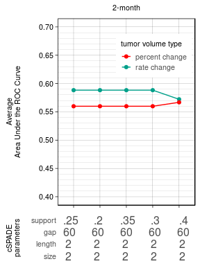

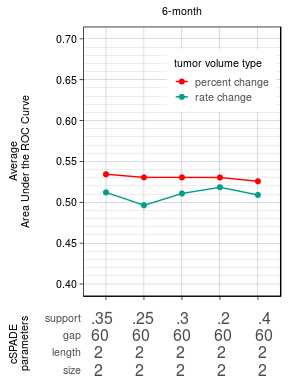

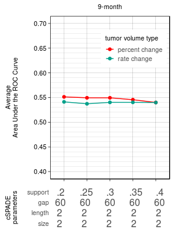

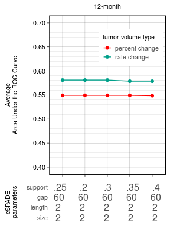

   ```r
   # individual plots
   spmROC <- lapply(months, function(m) plotCVResults(getCVByMonth(cvResults=cvs, m, 'rocAUC'),
                                            m,
                                            '' ) )
   ```

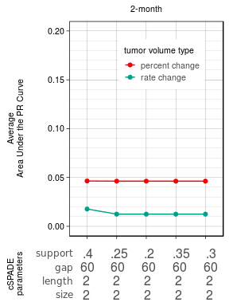

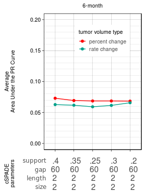

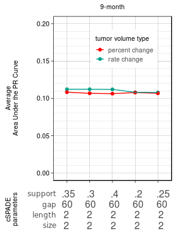

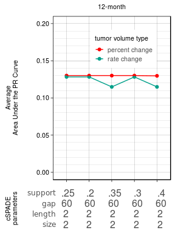

   ```r
   spmPR <- lapply(months, function(m) plotCVResults_PR(getCVByMonth(cvResults=cvs, m, 'prAUC'),
                                               m,
                                               '',
                                               c(.6,.8)) )
   ```

6. **Identify best model parameters from cross-validation**

   ```r
   # cv logit results
   bestLogitSpm <- lapply(months, function(m) {
     z <- cvs[which(cvs$month==m),]
     b <- z[which.max(z$rocAUC),]
     b <- b[,colnames(b) %in% c('rocAUC','rocAUCSD','tType','month','model', 'gap','length','name')]
     rownames(b) <- b$model
     b
   })
   bestLogitSpm <- do.call('rbind', bestLogitSpm)
   colnames(bestLogitSpm) <- c('rocAUC','rocAUCSD','month','name','model','maxgap','maxlength')
   bestLogitSpm$label <- getClassLabels() # assumes row order already matches
   bestLogitSpm$fitname <- c('fit2m','fit6m','fit9m','fit12m')
   bestLogitSpm
   ```

   ```
   #>                    rocAUC   rocAUCSD    month           name
   #> sup0.25g60l2z2  0.5882589 0.06704849  2-month    rate change
   #> sup0.35g60l2z2  0.5342622 0.06626262  6-month percent change
   #> sup0.2g60l2z2   0.5513217 0.02236023  9-month percent change
   #> sup0.25g60l2z21 0.5810034 0.01947099 12-month    rate change
   #>                          model maxgap maxlength      NA         label
   #> sup0.25g60l2z2  sup0.25g60l2z2     60         2 without  survivalIn60
   #> sup0.35g60l2z2  sup0.35g60l2z2     60         2 without survivalIn180
   #> sup0.2g60l2z2    sup0.2g60l2z2     60         2 without survivalIn270
   #> sup0.25g60l2z21 sup0.25g60l2z2     60         2 without survivalIn360
   #>                 fitname
   #> sup0.25g60l2z2    fit2m
   #> sup0.35g60l2z2    fit6m
   #> sup0.2g60l2z2     fit9m
   #> sup0.25g60l2z21  fit12m
   ```

7. **Plot the cross-valiation results**

   There is only one approach explored in this example, i.e., approach 3, using temporal patterns and patient covariates to predict residual survival. The paper explores 2 other approaches.

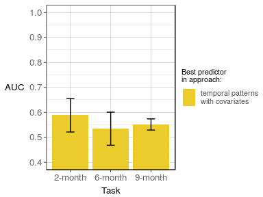

   ```r
   comp <- bestLogitSpm[,c('rocAUC','rocAUCSD','month','name')]
   comp$lower <- comp$rocAUC - comp$rocAUCSD
   comp$higher <- comp$rocAUC + comp$rocAUCSD
   comp$approach <- 3
   comp <- do.call('rbind', list(comp))
   comp$approach <- as.factor(comp$approach)
   comp$approach <- factor(comp$approach, levels=levels(comp$approach),
                           labels=c( 'temporal patterns\nwith covariates'))
   pd <- position_dodge(0.6) # move them .05 to the left and right

   comparedPlot <- ggplot(comp[!(comp$month=='12-month'),], aes(x=month, y=rocAUC, fill=factor(approach)) ) +
     geom_bar(stat='identity',position=position_dodge()) +
     scale_y_continuous(limits = c(.4,1), oob=rescale_none, breaks = seq(.4,1,0.1)) +
     theme_linedraw() +
     # ggtitle('') +
     perfTheme +
     geom_errorbar(aes(ymin=lower, ymax=higher), width=.2, position=position_dodge(.9)) +
     labs(fill='Best predictor\nin approach:') + xlab('Task') + ylab('AUC') +
     scale_fill_manual(values = wes_palette("Zissou1")[3:5] ) +
     theme(legend.text.align=0,
           legend.key.height=unit(1.5,'line'),
           legend.text = element_text(size=8),
           legend.title = element_text(size=8),
           axis.text=element_text(size=10),
           axis.title.y=element_text(size=10),
           axis.title.x=element_text(size=10)) +
     guides(fill = guide_legend(override.aes = list(size=6)))
   print(comparedPlot)
   ```

8. **Retrain and apply to test set**

   A model is selected, retrained on the training partition, and applied to the testing partition for each prediction task. For the sake of this example, let’s assume rate change as the tumor volume measurement was the best performer across all tasks.

   Prep for retraining:

   ```r
   seed <- 9
   metric <- 'rocAUC'
   expDir <- dirname(dataDir)

   # data partitions
   dataPartitions <- file.path(expDir, 'train_test_partitions.rds')
   partitions <- readRDS(file=dataPartitions)

   # unwanted features and labels that should not be in training data

   needToRemove <- c('id','iois','eventID', # remove ids
                     bestLogitSpm$label, # remove labels
                     'IDH1') # not interested

   # where to find the 'rate change' data for training
   selectedTType <- 'rate'
   selectedTTypeFN_spm <- 'featureVectors_rateChange.rds'
   selectedTTypeFN_cvLogit <- 'logits_CVresults_rateChange.rds'
   ```

   Get model performance results in retraining and testing:

   ```r
   retrainResults <- lapply(seq(1, nrow(bestLogitSpm)), function(i) {
     selected <- bestLogitSpm[i,]

     cat('\n....', selected$label ,' ...\n')

     # cv results
     cvLogitPath <- file.path(expDir,'logits', selected$model, selectedTTypeFN_cvLogit)
     cvResults <- readRDS(cvLogitPath)
     cvResults <- cvResults[[selected$fitname]]

     # get lambda from best cv results
     cvResults <- cvResults$avg.CVPerformance[which.max(cvResults$avg.CVPerformance$rocAUC),]
     cat('\n\n','Summary to repeated CV results (lambdas for retraining) ...\n\n')
     print(cvResults)


     # get data
     dataPath <- file.path(expDir,'spm', selected$model, selectedTTypeFN_spm)
     data <- readRDS(dataPath) # features and labels for each clinical visit
     names <- colnames(data)
     data <- data.frame(id=row.names(data),data)
     colnames(data) <- c('id',names)
     cat('... \n overall samples: ', nrow(data), '\n')

     data <- prepLaterality(data)
     data <- prepLocation(data)

     cat('... \n removing clinical visits with no history of length maxgap:', selected$maxgap, '\n')
     data <- removeVisits(data = data,
                          maxgap = as.numeric(as.character(selected$maxgap)),
                          maxlength = as.numeric(as.character(selected$maxlength)),
                          tType = selectedTType,
                          save=F,
                          outDir=outputDir)
     start.local <- Sys.time()
     cat('\n....', cvResults$lambda ,' ...\n')
     label <- selected$label

     fit <- retrainLogit(data = data[data$id %in% partitions$train,],  #training data
                         formula = as.formula(paste0(selected$label,'~.')),
                         labelName = selected$label,
                         lambda = cvResults$lambda,
                         lasso=TRUE, # using lamba
                         needToRemove=needToRemove,
                         createModelMatrix=FALSE,
                         metric=metric,
                         verbose=TRUE,
                         seed=seed)
     cat('\n'); print(Sys.time() - start.local)

     trainResults <-  getTrainResults(fit)
     testResults <- getTestResults(fit = fit,
                                   data = data[data$id %in% partitions$test,], #testing data
                                   labelName = selected$label,
                                   formula = as.formula(paste0(selected$label,'~.')),
                                   needToRemove=needToRemove,
                                   createModelMatrix=FALSE)

     testResults$selectedThreshold <-  trainResults$selectedThreshold # use the threshold selected from train

     list(fit=fit, train=trainResults, test=testResults)
   })
   ```

   ```
   #>
   #> .... survivalIn60  ...
   #>
   #>
   #>  Summary to repeated CV results (lambdas for retraining) ...
   #>
   #>          prAUC    rocAUC     prAUCSD   rocAUCSD lambda
   #> 100 0.01244991 0.5882589 0.006009641 0.06704849    0.2
   #> ...
   #>  overall samples:  1500
   #> ...
   #>  removing clinical visits with no history of length maxgap: 1
   #> ...visits left for training:  1340
   #>
   #> .... 0.2  ...
   #>
   #> Time difference of 0.5922754 secs
   #>
   #> .... survivalIn180  ...
   #>
   #>
   #>  Summary to repeated CV results (lambdas for retraining) ...
   #>
   #>         prAUC    rocAUC    prAUCSD  rocAUCSD     lambda
   #> 82 0.06175422 0.5121156 0.01104318 0.0866874 0.03747635
   #> ...
   #>  overall samples:  1500
   #> ...
   #>  removing clinical visits with no history of length maxgap: 1
   #> ...visits left for training:  1340
   #>
   #> .... 0.03747635  ...
   #>
   #> Time difference of 0.3993857 secs
   #>
   #> .... survivalIn270  ...
   #>
   #>
   #>  Summary to repeated CV results (lambdas for retraining) ...
   #>
   ```

   [output cut: 13 more lines]

   ```
   #>
   #>
   #>  Summary to repeated CV results (lambdas for retraining) ...
   #>
   #>        prAUC    rocAUC    prAUCSD   rocAUCSD    lambda
   #> 95 0.1282788 0.5810034 0.06671858 0.01947099 0.1256058
   #> ...
   #>  overall samples:  1500
   #> ...
   #>  removing clinical visits with no history of length maxgap: 1
   #> ...visits left for training:  1340
   #>
   #> .... 0.1256058  ...
   #>
   #> Time difference of 0.3910379 secs
   ```

   ```r
   names(retrainResults) <- bestLogitSpm$fitname
   ```

   Contents of retrainResults:

   ```r
   names(retrainResults) # for each model
   ```

   ```
   #> [1] "fit2m"  "fit6m"  "fit9m"  "fit12m"
   ```

   ```r
   names(retrainResults$fit2m) # for each prediction
   ```

   ```
   #> [1] "fit"   "train" "test"
   ```

   ```r
   names(retrainResults$fit2m$train) # results in train
   ```

   ```
   #> [1] "preds"             "performance"       "selectedThreshold"
   ```

   ```r
   names(retrainResults$fit2m$test) # results in test
   ```

   ```
   #> [1] "preds"             "performance"       "data"
   #> [4] "selectedThreshold"
   ```

   If we were to chose a threshold for classifiying 2-month residual survival, the results would be:

   ```r
   retrainResults$fit2m$train$selectedThreshold #train
   ```

   ```
   #>           selectROCThreshold(trainPred)
   #> cutoff                        0.6313534
   #> fp                           73.0000000
   #> tp                           10.0000000
   #> tn                          942.0000000
   #> fn                           12.0000000
   #> spec                          0.9280788
   #> sens                          0.4545455
   #> prec                          0.1204819
   #> recall                        0.4545455
   #> f1score                       0.1904762
   #> accuracy                      0.9180328
   #> cutoffInd                     2.0000000
   ```

   ```r
   retrainResults$fit2m$test$selectedThreshold #test
   ```

   ```
   #>           selectROCThreshold(trainPred)
   #> cutoff                        0.6313534
   #> fp                           73.0000000
   #> tp                           10.0000000
   #> tn                          942.0000000
   #> fn                           12.0000000
   #> spec                          0.9280788
   #> sens                          0.4545455
   #> prec                          0.1204819
   #> recall                        0.4545455
   #> f1score                       0.1904762
   #> accuracy                      0.9180328
   #> cutoffInd                     2.0000000
   ```

9. **Plot final model’s performance results in retraining and testing**

   Extract and structure the performance results:

   ```r
   rocsList <- lapply(retrainResults, function(fit) {list(train=fit$train$performance$roc,
                                                          test =fit$test$performance$roc )})
   aucsList <- lapply(retrainResults, function(fit) {list(train=fit$train$performance$aucROC,
                                                          test =fit$test$performance$aucROC )})
   prsList <- lapply(retrainResults, function(fit) {prs <- list(train=fit$train$performance$pr,
                                                                test =fit$test$performance$pr )})
   praucsList <- lapply(retrainResults, function(fit) {list(train=fit$train$performance$aucPR,
                                                            test =fit$test$performance$aucPR)})
   names(rocsList) <- months # assumes months and order of retrainResults are the same
   names(aucsList) <- months
   names(prsList) <- months
   names(praucsList) <- months
   ```

   Plot ROC and PR of final model’s test and train results

   ```r
   scaleColor <- scale_color_manual(values = c(wes_palette("Darjeeling1")[1], wes_palette('FantasticFox1')[3]) )
   lo <- c(2,3,4,1)

   finalModelROC <- plotMultiROC(fn = '',
                                 rocsList = rocsList[1:4],
                                 aucsList = aucsList[1:4],
                                 listOrder = lo,
                                 outDir = NULL,
                                 legendTitle = 'data\npartition',
                                 printIt=F,
                                 perfTheme = perfTheme,
                                 scaleX = scaleX,
                                 scaleY = scaleY,
                                 perfGuide = perfGuide) +
     theme(legend.text.align=0) +
     scaleColor
   finalModelPR <- plotMultiPR(fn = '',
                               prsList = prsList[1:4],
                               aucsList = praucsList[1:4],
                               legendTitle = 'data\npartition',
                               outDir = NULL,
                               listOrder = lo,
                               printIt=F,
                               perfTheme = perfTheme,
                               scaleX = scaleX,
                               scaleY = scaleY,
                               perfGuide = perfGuide) +
     theme(legend.text.align=0) +
     scaleColor
   ```

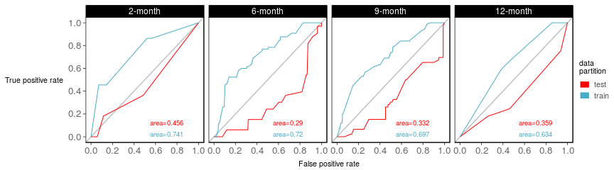

   ```r
   print(finalModelROC)
   ```

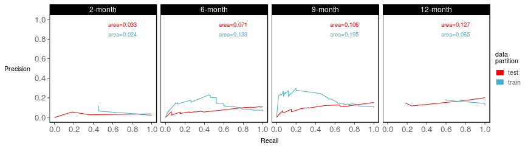

   ```r
   print(finalModelPR)
   ```